# Clustered standard errors with R: Three ways, one result

Markus Konrad

2021-05-17

## Introduction

In many scenarios, data are structured in groups or clusters, e.g. pupils within classes (within schools), survey respondents within countries or, for longitudinal surveys, survey answers per subject Simply ignoring this structure will likely lead to spuriously low standard errors, i.e. a misleadingly precise estimate of our coefficients. This in turn leads to overly-narrow confidence intervals, overly-low p-values and possibly wrong conclusions.

*Clustered standard errors* are a common way to deal with this problem. Unlike Stata, R doesn’t have built-in functionality to estimate clustered standard errors. There are several packages though that add this functionality and this article will introduce three of them, explaining how they can be used and what their advantages and disadvantages are. Before that, I will outline the theory behind (clustered) standard errors for linear regression. The last section is used for a performance comparison between the three presented packages. If you’re already familiar with the concept of clustered standard errors, you may skip to the hands-on part right away.

## Data

We’ll work with the dataset *nlswork* that’s [included in Stata](https://www.stata-press.com/data/r16/), so we can easily compare the results with Stata. The data comes from the US National Longitudinal Survey (NLS) and contains information about more than 4,000 young working women. As for this example, we’re interested in the relationship between wage (here as log-scaled GNP-adjusted wage) as dependent variable (DV) `ln_wage` and survey participant’s current `age`, job `tenure` in years and `union` membership as independent variables. It’s a longitudinal survey, so subjects were asked repeatedly between 1968 and 1988 and each subject is identified by an unique `idcode`.

The example data is used for illustrative purposes only and we skip many things that we’d normally do, such as investigating descriptive statistics and exploratory plots. To keep the data size limited, we’ll only work with a subset of the data (only subjects with IDs 1 to 100) and we also simply dismiss any observations that contain missing values.

```r
library(webuse)
library(dplyr)

#nlswork_orig <- webuse('nlswork')
nlswork_orig <- readRDS('cache/nlswork.RDS')

nlswork <- filter(nlswork_orig, idcode <= 100) %>%
  select(idcode, year, ln_wage, age, tenure, union) %>%
  filter(complete.cases(.)) %>%
  mutate(union = as.integer(union),
         idcode = as.factor(idcode))
str(nlswork)
```

```
## tibble [386 × 6] (S3: tbl_df/tbl/data.frame)
##  $ idcode : Factor w/ 82 levels "1","2","3","4",..: 1 1 1 1 1 1 1 2 2 2 ...
##  $ year   : num [1:386] 72 77 80 83 85 87 88 71 77 78 ...
##   ..- attr(*, "label")= chr "interview year"
##   ..- attr(*, "format.stata")= chr "%8.0g"
##  $ ln_wage: num [1:386] 1.59 1.78 2.55 2.42 2.61 ...
##   ..- attr(*, "label")= chr "ln(wage/GNP deflator)"
##   ..- attr(*, "format.stata")= chr "%9.0g"
##  $ age    : num [1:386] 20 25 28 31 33 35 37 19 25 26 ...
##   ..- attr(*, "label")= chr "age in current year"
##   ..- attr(*, "format.stata")= chr "%8.0g"
##  $ tenure : num [1:386] 0.917 1.5 1.833 0.667 1.917 ...
##   ..- attr(*, "label")= chr "job tenure, in years"
##   ..- attr(*, "format.stata")= chr "%9.0g"
##  $ union  : int [1:386] 1 0 1 1 1 1 1 0 1 1 ...
##  - attr(*, "label")= chr "National Longitudinal Survey.  Young Women 14-26 years of age in 1968"
```

Let’s have a look at the first few observations. They contain data from subject #1, who was surveyed several times between 1972 and 1988, and a few observations from subject #2.

```r
head(nlswork, 10)
```

```
## # A tibble: 10 x 6
##    idcode  year ln_wage   age tenure union
##    <fct>  <dbl>   <dbl> <dbl>  <dbl> <int>
##  1 1         72    1.59    20  0.917     1
##  2 1         77    1.78    25  1.5       0
##  3 1         80    2.55    28  1.83      1
##  4 1         83    2.42    31  0.667     1
##  5 1         85    2.61    33  1.92      1
##  6 1         87    2.54    35  3.92      1
##  7 1         88    2.46    37  5.33      1
##  8 2         71    1.36    19  0.25      0
##  9 2         77    1.73    25  2.67      1
## 10 2         78    1.69    26  3.67      1
```

```r
summary(nlswork)
```

```
##      idcode         year          ln_wage            age           tenure
##  9      : 12   Min.   :70.00   Min.   :0.4733   Min.   :18.0   Min.   : 0.000
##  20     : 12   1st Qu.:73.00   1st Qu.:1.6131   1st Qu.:25.0   1st Qu.: 1.167
##  6      : 11   Median :80.00   Median :1.9559   Median :31.0   Median : 2.417
##  16     : 11   Mean   :79.61   Mean   :1.9453   Mean   :30.8   Mean   : 3.636
##  22     : 11   3rd Qu.:85.00   3rd Qu.:2.2349   3rd Qu.:36.0   3rd Qu.: 4.958
##  24     : 11   Max.   :88.00   Max.   :3.5791   Max.   :45.0   Max.   :19.000
##  (Other):318
##      union
##  Min.   :0.0000
##  1st Qu.:0.0000
##  Median :0.0000
##  Mean   :0.2591
##  3rd Qu.:1.0000
##  Max.   :1.0000
##
```

We have 82 subjects in our subset:

```r
length(unique(nlswork$idcode))
```

```
## [1] 82
```

The number of times each subject was surveyed ranges from only once to twelve times:

```r
summary(as.integer(table(nlswork$idcode)))
```

```
##    Min. 1st Qu.  Median    Mean 3rd Qu.    Max.
##   1.000   2.000   4.000   4.707   7.000  12.000
```

In more than one quarter of the observations, the subject answered to be currently member of a trade union:

```r
table(nlswork$union)
```

```
##
##   0   1
## 286 100
```

The following shows the distribution of the DV in our data.

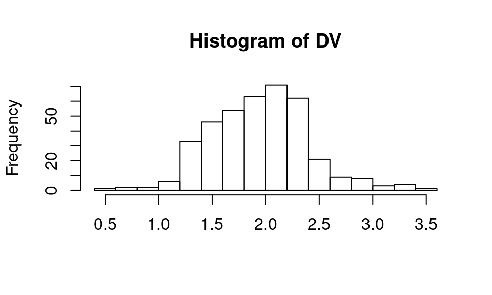

```r
hist(nlswork$ln_wage, breaks = 20, main = 'Histogram of DV', xlab = NA)
```

The DV is roughly normally distributed with the following mean and SD:

```r
c(mean(nlswork$ln_wage), sd(nlswork$ln_wage))
```

```
## [1] 1.9453220 0.4506576
```

We can calculate the mean and SD of the DV separately for each subject. A histogram of these subject-specific means reveals more variability:

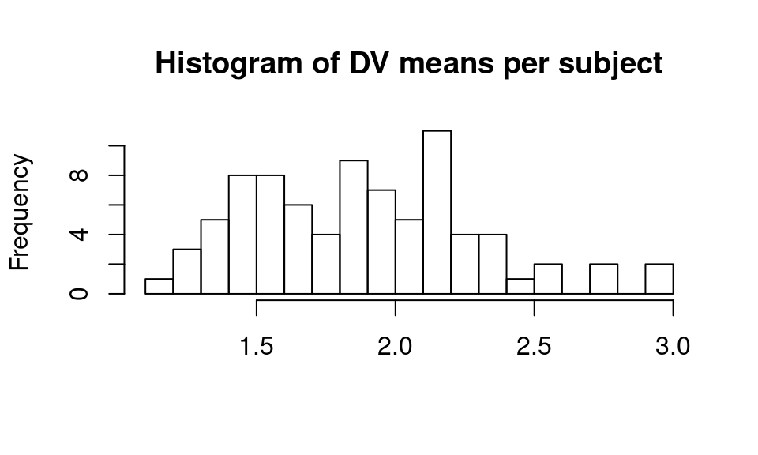

```r
y_mean_sd_cl <- sapply(levels(nlswork$idcode), function(idcode) {
  y_cl <- nlswork$ln_wage[nlswork$idcode == idcode]
  c(mean(y_cl), sd(y_cl))
})
hist(y_mean_sd_cl[1,], breaks = 20, main = 'Histogram of DV means per subject', xlab = NA)
```

We can compare the SD of the subject-specific means with the mean of the SDs calculated from each subjects’ repeated measures.

```r
c(sd(y_mean_sd_cl[1,]), mean(y_mean_sd_cl[2,], na.rm = TRUE))
```

```
## [1] 0.4038449 0.2221142
```

The SD between the subject-specific means is almost twice as large as the mean of the SD from each subjects’ values. This shows that there’s much more variability between each subject than within each subject’s repeated measures regarding the DV.

## Fixed-effects model, not adjusting for clustered observations

Our data contains repeated measures for each subject, so we have panel data in which each subject forms a group or cluster. We can use a fixed-effects (FE) model to account for unobserved subject-specific characteristics. We do so by including the subject’s `idcode` in our model formula. It’s important to note that `idcode` is of type factor (we applied `idcode = as.factor(idcode)` when we prepared the data) so that for each factor level (i.e. each subject) an FE coefficient will be estimated that represents the subject-specific mean of our DV.[^1]

Let’s specify and fit such a model using `lm`. We include job `tenure`, `union` membership and an interaction between both (the latter mainly for illustrative purposes later when we estimate marginal effects). We also control for `age` and add `idcode` as FE variable.

```r
m1 <- lm(ln_wage ~ age + tenure + union + tenure:union + idcode,
         data = nlswork)
summary(m1)
```

```
##
## Call:
## lm(formula = ln_wage ~ age + tenure + union + tenure:union +
##     idcode, data = nlswork)
##
## Residuals:
##      Min       1Q   Median       3Q      Max
## -0.96463 -0.09405  0.00000  0.11460  1.23525
##
## Coefficients:
##                Estimate Std. Error t value Pr(>|t|)
## (Intercept)   1.882e+00  1.314e-01  14.325  < 2e-16 ***
## age           5.631e-03  3.110e-03   1.811 0.071193 .
## tenure        2.076e-02  6.964e-03   2.980 0.003115 **
## union         1.746e-01  6.065e-02   2.879 0.004272 **
## idcode2      -6.174e-01  1.285e-01  -4.803 2.47e-06 ***
## idcode3      -5.625e-01  1.329e-01  -4.234 3.05e-05 ***
## idcode4      -3.006e-01  1.291e-01  -2.329 0.020524 *
## idcode5      -1.927e-01  1.422e-01  -1.355 0.176494
## idcode6      -4.486e-01  1.318e-01  -3.403 0.000756 ***
...
```

We’re not really interested in the subject-specific means (the FE coefficients), so let’s filter them out and only show our coefficients of interest:

```r
m1coeffs_std <- data.frame(summary(m1)$coefficients)
coi_indices <- which(!startsWith(row.names(m1coeffs_std), 'idcode'))
m1coeffs_std[coi_indices,]
```

```
##                 Estimate  Std..Error   t.value     Pr...t..
## (Intercept)  1.882478232 0.131411504 14.325064 8.022367e-36
## age          0.005630809 0.003109803  1.810664 7.119315e-02
## tenure       0.020756426 0.006964417  2.980353 3.114742e-03
## union        0.174619394 0.060646038  2.879321 4.272027e-03
## tenure:union 0.014974113 0.009548509  1.568215 1.178851e-01
```

Unsurprisingly, job tenure and especially union membership are positively associated with wage. The coefficient of the interaction term shows that with union membership the job tenure effect is even a bit higher, though not significantly.

In the next two sections we’ll see how standard errors for our estimates are usually computed and how this fits into a framework called “sandwich estimators.” Using this framework, we’ll see how the standard error calculations can be adjusted for clustered data.

## Standard errors

In ordinary least squares (OLS) regression, we assume that the regression model errors are independent. This is not the case here: Each subject may be surveyed several times so within each subject’s repeated measures, the errors will be correlated. Although that is not a problem for our regression estimates (they are still unbiased – Roberts (2013)), it *is* a problem for for the precision of our estimates – the precision will typically be overestimated, i.e. the standard errors (SEs) will be lower than they should be (Cameron and Miller 2013). The intuition behind this regarding our example is that within our clusters we usually have lower variance since the answers come from the same subject and are correlated. This lowers our estimates’ SEs.

We can deal with this using *clustered standard errors* with subjects representing our clusters. But before we do this, let’s first have a closer look on how “classic” OLS estimates’ SEs are actually computed.

In matrix notation, a linear model has the form

$$Y = X\beta + e.$$
This model has $p$ parameters (including the intercept parameter $\beta_0$) expressed as $p \times 1$ parameter vector $\beta$. The parameters will be estimated from $n$ observations in our data. The DV is $Y$ (an $n \times 1$ vector), the independent variables form an $n \times p$ matrix $X$. Finally, the error term $e$ is an $n \times 1$ vector that captures everything that influences $Y$ but cannot be explained by $X\beta$. In classic OLS, we assume that $e$ has a mean of zero and a variance of $\sigma^2$.

By minimizing $e = Y - X\beta$ an estimation for our parameters, $\hat\beta$, can be found as $\hat\beta = (X^TX)^{-1}Y$. The estimated variance $\hat V[\hat\beta]$ for these parameters is then

$$\begin{equation}
\hat V[\hat\beta] = \hat\sigma^2 (X^TX)^{-1},
\tag{1}
\end{equation}$$

where $\hat\sigma^2$ is the estimated variance of the error or *residual variance*. This is calculated as

$$\hat\sigma^2 = \frac{\sum^n_{i=1} \hat e_i^2}{n-p},$$

with $\hat e_i$ being the residuals. The numerator is also called the *residual sum of squares* and the denominator is the *degrees of freedom*.

You can see for example Sheather (2009) for how the formulas for $\hat\beta$ and $\hat V[\hat\beta]$ are derived or [watch this video for a clear step-by-step derivation](https://www.youtube.com/watch?v=jyBtfhQsf44).

We now have all the pieces together to replicate the standard errors from model `m1` with our own calculations. To translate these formulae to R, we use `model.matrix` to get the design matrix $X$, `residuals` for the residual vector $\hat e$, `nobs` for the number of observations $n$, `ncol(X)` for the number or parameters, `solve` to calculate the inverse of $X^T X$ and `diag` to extract the diagonal of a square matrix.

```r
X <- model.matrix(m1)
u <- residuals(m1)
n <- nobs(m1)
p <- ncol(X)
sigma2 <- sum(u^2) / (n - p)
# solve (X^T X) A = I, where I is identity matrix -> A is (X^T X)^-1
crossXinv <- solve(t(X) %*% X, diag(p))
m1se <- sqrt(diag(sigma2 * crossXinv))
m1se
```

```
##  [1] 0.131411504 0.003109803 0.006964417 0.060646038 0.128532897 0.132850020
##  [7] 0.129073913 0.142197527 0.131807814 0.154288821 0.134842179 0.154786225
## [13] 0.217550496 0.139150254 0.211281877 0.135754047 0.131627656 0.147338973
...
```

Let’s check if this is equal to the standard errors calculated by `lm` (using `near` because of minor deviations due to floating point number imprecision):

```r
all(near(m1se, m1coeffs_std$Std..Error))
```

```
## [1] TRUE
```

We extracted our parameter estimates’ variance $\hat V[\hat\beta]$ from the diagonal of the *(variance-)covariance* or *vcov* matrix and R has the `vcov` function to calculate it from a fitted model. It’s exactly what we computed before using eq. 1:

```r
all(near(sigma2 * crossXinv, vcov(m1)))
```

```
## [1] TRUE
```

## Clustered standard errors

Classic OLS SEs can be generalized so that some assumptions, namely that the regression model errors are independent, can be relaxed. The foundation for this is the *sandwich estimator*[^2]

$$\begin{equation}
\hat V[\hat\beta] = (X^TX)^{-1} X^T \boldsymbol\Omega X (X^TX)^{-1}.
\tag{2}
\end{equation}$$

Let’s first understand how the above equation relates to eq. 1, the classic OLS parameter variance: One assumption of classic OLS is [constant variance (or homoscedasticity)](https://bookdown.org/roback/bookdown-BeyondMLR/ch-MLRreview.html#assumptions-for-linear-least-squares-regression) in the errors across the full spectrum of our DV. This implicates that $\Omega$ is a diagonal matrix with identical $\hat\sigma^2$ elements, i.e. $\boldsymbol\Omega = \hat\sigma^2I$. Plugging this into eq. 2 gives eq. 1 which shows that the classic OLS parameter variance is a specialized form of the sandwich estimator.[^3]

When we want to obtain clustered SEs, we need to consider that $\Omega$ in the “meat” part of eq. 2 is *not* a diagonal matrix with identical $\hat\sigma^2$ elements anymore, hence this can’t be simplified to eq. 1. Instead, we can assume that $\Omega$ is block-diagonal with the clusters forming the blocks. This means we assume that the variance in the errors is constant only *within clusters* and so we first calculate $\Omega_j$ per cluster $j$ and then sum the $\Omega_j$. Cameron and Miller (2013) (p. 11) shows how $\Omega$ is calculated in detail and also which finite-sample correction factor is applied. From this article we get the equation

$$\begin{equation}
\Omega = \frac{n-1}{n-p}\frac{c}{c-1} \sum_{j=1}^c (X_j^T \hat e_j \hat e_j^T X_j),
\tag{3}
\end{equation}$$

where $c$ is the number of clusters. It’s interesting to see how the residuals are added up *per cluster* and then averaged. As Cameron and Miller (2013) (p. 13) notes, this implicates an important limitation: With a low number of clusters, this averaging is imprecise.

Let’s translate this formula to R. We already have $\hat e$ as `u` (the residuals) and the design matrix `X`. We can generate a list of matrices $\Omega_j$, sum them and multiply the correction factor:

```r
omegaj <- lapply(levels(nlswork$idcode), function(idcode) {
  j <- nlswork$idcode == idcode
  X_j <- X[j, , drop = FALSE]           # don't drop dimensions when we have only one obs.
  t(X_j) %*% tcrossprod(u[j]) %*% X_j   # tcrossprod is outer product x * x^T
})

n_cl <- length(levels(nlswork$idcode))  # num. clusters
#                 correction factor          *   sum of omega_j
omega <- (n-1) / (n-p) * (n_cl / (n_cl-1)) * Reduce('+', omegaj)
# sandwich formula; extract diagonal and take square root to get SEs
m1clse <- sqrt(diag(crossXinv %*% omega %*% crossXinv))
m1clse[1:5]   # only showing the first 5 values here
```

```
## [1] 0.157611390 0.006339777 0.011149190 0.101970509 0.020561516
```

We will later check that this matches the estimates calculated with R packages that implement clustered SE estimation. For now, let’s compare the classic OLS SEs with the clustered SEs:

```r
m1coeffs_with_clse <- cbind(m1coeffs_std, ClustSE = m1clse)
m1coeffs_with_clse[coi_indices, c(1, 2, 5)]
```

```
##                 Estimate  Std..Error     ClustSE
## (Intercept)  1.882478232 0.131411504 0.157611390
## age          0.005630809 0.003109803 0.006339777
## tenure       0.020756426 0.006964417 0.011149190
## union        0.174619394 0.060646038 0.101970509
## tenure:union 0.014974113 0.009548509 0.009646023
```

We can see that, as expected, the clustered SEs are all a bit higher than the classic OLS SEs.

The above calculations were used to show what’s happening “under the hood” and also how the formulas used for these calculations are motivated. However, doing these calculations “by hand” is error-prone and slow. It’s better to use well trusted packages for daily work and so next we’ll have a look at some of these packages and how they can be used. Still, it’s helpful to understand some background and the limitations for this approach. See Cameron and Miller (2013) for a much more thorough guide (though only with examples in Stata) that also considers topics like which variable(s) to use for clustering, what to do when dealing with a low number of clusters or how to implement multi-way clustering.

## Option 1: *sandwich* and *lmtest*

The [*sandwich* package](https://cran.r-project.org/web/packages/sandwich/index.html) implements several methods for robust covariance estimators, including clustered SEs. Details are explained in Zeileis, Köll, and Graham (2020). The accompanying [*lmtest* package](https://cran.r-project.org/web/packages/lmtest/index.html) provides functions for coefficient tests that take into account the calculated robust covariance estimates.

As explained initially, the parameter estimates from our model are fine despite the clustered structure of our data. But the SEs are likely biased downward and need to be corrected. This is why we can resume to work with our initially estimated model `m1` from `lm`. There’s no need to refit it and sandwich works with lm model objects (and also some other types of models such as some glm models). We only have to adjust how we test our coefficient estimates in the following way:

1. We need to use [`coeftest`](https://rdrr.io/cran/lmtest/man/coeftest.html) from the lmtest package;
2. we need to pass it our model and either a function to calculate the covariance matrix or an already estimated covariance matrix to the `vcov` parameter;
3. we need to specify a cluster variable in the `cluster` parameter.

The sandwich package provides several functions for estimating robust covariance matrices. We need [`vcovCL`](https://rdrr.io/rforge/sandwich/man/vcovCL.html) for clustered covariance estimation and will pass this function as `vcov` parameter. Furthermore, we cluster by subject ID, so the cluster variable is `idcode`.

```r
library(sandwich)
library(lmtest)

m1coeffs_cl <- coeftest(m1, vcov = vcovCL, cluster = ~idcode)
m1coeffs_cl[coi_indices,]
```

```
##                 Estimate  Std. Error    t value     Pr(>|t|)
## (Intercept)  1.882478232 0.157611390 11.9437956 3.667970e-27
## age          0.005630809 0.006339777  0.8881715 3.751601e-01
## tenure       0.020756426 0.011149190  1.8616981 6.362342e-02
## union        0.174619394 0.101970509  1.7124500 8.784708e-02
## tenure:union 0.014974113 0.009646023  1.5523613 1.216301e-01
```

The calculated SE values seem familiar and they are indeed equal to what we calculated before as `m1clse` “by hand”:

```r
all(near(m1clse, m1coeffs_cl[,2]))
```

```
## [1] TRUE
```

The lmtest package provides several functions for common post-estimation tasks, for example [`coefci`](https://rdrr.io/cran/lmtest/man/coefci.html) to calculate confidence intervals (CIs). If we use these, we need to make sure to specify the same type of covariance estimation, again by passing the appropriate `vcov` and `cluster` parameters:

```r
coefci(m1, parm = coi_indices, vcov = vcovCL, cluster = ~idcode)
```

```
##                     2.5 %     97.5 %
## (Intercept)   1.572314302 2.19264216
## age          -0.006845258 0.01810688
## tenure       -0.001184099 0.04269695
## union        -0.026048678 0.37528746
## tenure:union -0.004008324 0.03395655
```

This is really important, as otherwise the classic (non-clustered) covariance estimation is applied by default. This, due to lower SEs, leads to narrower CIs:

```r
(m1cis <- coefci(m1, parm = coi_indices))
```

```
##                      2.5 %     97.5 %
## (Intercept)   1.6238731375 2.14108333
## age          -0.0004889822 0.01175060
## tenure        0.0070511278 0.03446172
## union         0.0552738733 0.29396491
## tenure:union -0.0038164264 0.03376465
```

Here, the `tenure` and `union` CIs suddenly don’t include zero any more!

Instead of passing `vcovCL` as function to the `vcov` parameter, it’s more convenient and computationally more efficient to calculate the covariance matrix only once using `vcovCL` and then passing this matrix to functions like `coeftest` and `coefci` instead:

```r
cl_vcov_mat <- vcovCL(m1, cluster = ~idcode)
```

Now we pass this matrix for the `vcov` parameter. We don’t need to specify the `cluster` parameter anymore, since this information was only needed in the previous step.

```r
m1coeffs_cl2 <- coeftest(m1, vcov = cl_vcov_mat)
all(near(m1coeffs_cl[,2], m1coeffs_cl2[,2]))       # same SEs?
```

```
## [1] TRUE
```

```r
m1cis2 <- coefci(m1, parm = coi_indices, vcov = cl_vcov_mat)
all(near(m1cis2, m1cis2))       # same CIs?
```

```
## [1] TRUE
```

Another example would be to calculate marginal effects, for example with the [*margins*](https://cran.r-project.org/web/packages/margins/index.html) package. Again, to arrive at clustered SEs we will need to pass the proper covariance matrix via the `vcov` parameter. We do this for the marginal effect of `tenure` at the two levels of `union`:

```r
library(margins)

margins(m1, vcov = cl_vcov_mat, variables = 'tenure', at = list(union = 0:1)) %>%
  summary()
```

```
##  factor  union    AME     SE      z      p   lower  upper
##  tenure 0.0000 0.0208 0.0111 1.8617 0.0626 -0.0011 0.0426
##  tenure 1.0000 0.0357 0.0083 4.3089 0.0000  0.0195 0.0520
```

Otherwise classic SEs are estimated, which are smaller:

```r
margins(m1, variables = 'tenure', at = list(union = 0:1)) %>% summary()
```

```
##  factor  union    AME     SE      z      p  lower  upper
##  tenure 0.0000 0.0208 0.0070 2.9804 0.0029 0.0071 0.0344
##  tenure 1.0000 0.0357 0.0081 4.3846 0.0000 0.0198 0.0517
```

As you can see, the combination of `lm` and the packages sandwich and lmtest are all you need for estimating clustered SEs and inference. However, you really need to be careful to include the covariance matrix at all steps of your calculations.

## Option 2: `lm.cluster` from *miceadds*

There’s also `lm.cluster` from the package [*miceadds*](https://cran.r-project.org/web/packages/miceadds/index.html)[^4], which may be a bit more convenient to use. Internally, it basically does the same that we’ve done before by employing sandwich’s `vcovCL` (see source code parts [here](https://github.com/alexanderrobitzsch/miceadds/blob/ca9e54c18e9743280b9a075e6e119fec38693af2/R/lm.cluster.R#L33) and [there](https://github.com/alexanderrobitzsch/miceadds/blob/ca9e54c18e9743280b9a075e6e119fec38693af2/R/lm_cluster_compute_vcov.R#L13) for example).

Instead of using `lm`, we fit the model with `lm.cluster` and specify a cluster variable (this time as string, not as formula). The model summary then contains the clustered SEs:

```r
library(miceadds)

m2 <- lm.cluster(ln_wage ~ age + tenure + union + tenure:union + idcode,
                 cluster = 'idcode',
                 data = nlswork)
m2coeffs <- data.frame(summary(m2))
```

```r
m2coeffs[!startsWith(row.names(m2coeffs), 'idcode'),]
```

```
##                 Estimate  Std..Error    t.value     Pr...t..
## (Intercept)  1.882478232 0.157611390 11.9437956 6.995639e-33
## age          0.005630809 0.006339777  0.8881715 3.744485e-01
## tenure       0.020756426 0.011149190  1.8616981 6.264565e-02
## union        0.174619394 0.101970509  1.7124500 8.681378e-02
## tenure:union 0.014974113 0.009646023  1.5523613 1.205758e-01
```

An object `m` that is returned from `lm.cluster` is a list that contains the `lm` object as `m$lmres` and the covariance matrix as `m$vcov`. Again, these objects need to be “dragged along” if we want to do further computations. For `margins`, we also need to pass the data again via `data = nlswork`:

```r
margins(m2$lm_res, vcov = m2$vcov, variables = 'tenure', at = list(union = 0:1), data = nlswork) %>%
  summary()
```

```
##  factor  union    AME     SE      z      p   lower  upper
##  tenure 0.0000 0.0208 0.0111 1.8617 0.0626 -0.0011 0.0426
##  tenure 1.0000 0.0357 0.0083 4.3089 0.0000  0.0195 0.0520
```

The result is consistent with our former computations. The advantage over the “lm + sandwich + lmtest” approach is that you can do clustered SE estimation and inference in one go. For further calculations you still need to be careful to supply the covariance matrix from `m$vcov`.

## Option 3: `lm_robust` from *estimatr*

Another option is to use [`lm_robust`](https://declaredesign.org/r/estimatr/articles/getting-started.html#lm_robust) from the [*estimatr*](https://cran.r-project.org/web/packages/estimatr/index.html) package which is part of the [DeclareDesign framework](https://declaredesign.org/) (Blair et al. 2019). Like `lm.cluster`, it’s more convenient to use, but it doesn’t rely on sandwich and lmtest in the background and instead comes with an own implementation for model fitting and covariance estimation. This implementation is [supposed to be faster](https://declaredesign.org/r/estimatr/#fast-to-use) than the other approaches and we’ll check that for our example later.

But first, let’s fit a model with clustered SEs using `lm_robust`. We use the same formula as with `lm` or `lm.cluster`, but also specify the `clusters` parameter:[^5]

```r
library(estimatr)

m3 <- lm_robust(ln_wage ~ age + tenure + union + tenure:union + idcode,
                clusters = idcode,
                data = nlswork)
summary(m3)
```

```
##
## Call:
## lm_robust(formula = ln_wage ~ age + tenure + union + tenure:union +
##     idcode, data = nlswork, clusters = idcode)
##
## Standard error type:  CR2
##
## Coefficients:
##                Estimate Std. Error    t value  Pr(>|t|)   CI Lower  CI Upper
## (Intercept)   1.882e+00   0.141424  13.310872 8.596e-14  1.5930761  2.171880
## age           5.631e-03   0.005726   0.983442 3.342e-01 -0.0061215  0.017383
## tenure        2.076e-02   0.010089   2.057345 5.771e-02 -0.0007714  0.042284
## union         1.746e-01   0.093790   1.861817 7.735e-02 -0.0209918  0.370231
## idcode2      -6.174e-01   0.019094 -32.334722 2.810e-07 -0.6656871 -0.569086
## idcode3      -5.625e-01   0.078607  -7.156034 9.687e-07 -0.7273116 -0.397718
...
```

Unlike `lm`, `lm_robust` allows to specify fixed effects in a separate `fixed_effects` formula parameter which, according to the [documentation](https://rdrr.io/cran/estimatr/man/lm_robust.html), should speed up computation for many types of SEs. Furthermore, this cleans up the summary output since there are no more FE coefficients:

```r
m3fe <- lm_robust(ln_wage ~ age + tenure + union + tenure:union,
                  clusters = idcode,
                  fixed_effects = ~idcode,
                  data = nlswork)
summary(m3fe)
```

```
##
## Call:
## lm_robust(formula = ln_wage ~ age + tenure + union + tenure:union,
##     data = nlswork, clusters = idcode, fixed_effects = ~idcode)
##
## Standard error type:  CR2
##
## Coefficients:
##              Estimate Std. Error t value Pr(>|t|)   CI Lower CI Upper     DF
## age          0.005631   0.005726  0.9834  0.33419 -0.0061215  0.01738 26.790
## tenure       0.020756   0.010089  2.0573  0.05771 -0.0007714  0.04228 14.812
## union        0.174619   0.093790  1.8618  0.07735 -0.0209918  0.37023 20.049
## tenure:union 0.014974   0.009043  1.6558  0.14062 -0.0062982  0.03625  7.187
##
## Multiple R-squared:  0.7554 ,    Adjusted R-squared:  0.6861
## Multiple R-squared (proj. model):  0.199 ,   Adjusted R-squared (proj. model):  -0.02795
## F-statistic (proj. model): 17.56 on 4 and 81 DF,  p-value: 2.071e-10
```

```r
m3fe_df <- tidy(m3fe) %>% rename(est.lm_robust = estimate,
                                 se.lm_robust = std.error)
m3fe_df$se.sandwich <-  m1coeffs_cl[coi_indices,2][2:5]
m3fe_df$est.classic <-  m1coeffs_std[coi_indices,1][2:5]
m3fe_df$se.classic <-  m1coeffs_std[coi_indices,2][2:5]
m3fe_df[c('term', 'est.classic', 'est.lm_robust', 'se.classic', 'se.lm_robust', 'se.sandwich')]
```

```
##           term est.classic est.lm_robust  se.classic se.lm_robust se.sandwich
## 1          age 0.005630809   0.005630809 0.003109803  0.005725617 0.006339777
## 2       tenure 0.020756426   0.020756426 0.006964417  0.010088940 0.011149190
## 3        union 0.174619394   0.174619394 0.060646038  0.093789776 0.101970509
## 4 tenure:union 0.014974113   0.014974113 0.009548509  0.009043429 0.009646023
```

This is because `lm_robust` by default uses a different cluster-robust variance estimator *“to correct hypotheses tests for small samples and work with commonly specified fixed effects and weights”* as explained in the [*Getting started* vignette](https://declaredesign.org/r/estimatr/articles/getting-started.html#lm_robust). Details can be found in the [Mathematical notes for estimatr](https://declaredesign.org/r/estimatr/articles/mathematical-notes.html#cluster-robust-variance-and-degrees-of-freedom).

As with the `lm` and `lm.cluster` results, we can also estimate marginal effects with a `lm_robust` result object. However, this doesn’t seem to work when you specify FEs via `fixed_effects` parameter as done for `m3fe`:

```r
margins(m3fe, variables = 'tenure', at = list(union = 0:1)) %>%
  summary()      # doesn't work
# -> Error in predict.lm_robust(model, newdata = data, type = type, se.fit = TRUE, :
#    Can't set `se.fit` == TRUE with `fixed_effects`
```

With `m3` (where FEs were directly specified in the model formula), marginal effects estimation works and we don’t even need to pass a separate `vcov` matrix, since this information already comes with the `lm_robust` result object `m3`.[^6]

```r
margins(m3, variables = 'tenure', at = list(union = 0:1)) %>% summary()
```

```
##  factor  union    AME     SE      z      p  lower  upper
##  tenure 0.0000 0.0208 0.0101 2.0573 0.0397 0.0010 0.0405
##  tenure 1.0000 0.0357 0.0077 4.6174 0.0000 0.0206 0.0509
```

As already said, `lm_robust` uses a different variance estimator than sandwich’s `vcovCL` and Stata. However, by setting `se_type` to `'stata'` we can replicate these “Stata Clustered SEs”:

```r
m3stata <- lm_robust(ln_wage ~ age + tenure + union + tenure:union + idcode,
                     clusters = idcode,
                     se_type = 'stata',
                     data = nlswork)
m3stata_se <- tidy(m3stata) %>% pull(std.error)
all(near(m3stata_se, m1clse))  # same SEs?
```

```
## [1] TRUE
```

In summary, `lm_robust` is as convenient to use as `lm` or `lm.cluster`, but offers similar flexibility as `sandwich` for estimating clustered SEs. A big advantage is that you don’t need to care about supplying the right covariance matrix to further post-estimation functions like `margins`. The proper covariance matrix is directy attached to the fitted `lm_robust` object (and can by accessed via `model$vcov` or `vcov(model)` if you need to). Is parameter estimation also faster with `lm_robust`?

## Performance comparison

We’ll make a rather superficial performance comparison only using the `nlswork` dataset and [microbenchmark](https://cran.r-project.org/web/packages/microbenchmark/index.html). We will compare the following implementations for estimating model coefficients and clustered SEs:

1. `lm` and `vcovCL` from sandwich
2. `lm.cluster`
3. `lm_robust` with default SEs (`se_type = 'CR2'`)
4. `lm_robust` with Stata SEs (`se_type = 'stata'`)
5. `lm_robust` with `fixed_effects` parameter and Stata SEs (`fixed_effects = idcode, se_type = 'stata'`)

For a fair comparison, we don’t calculate CIs (which `lm_robust` by default does). These are the results for 100 test runs:

```
## Unit: milliseconds
##      expr       min        lq      mean    median        uq      max neval
##  1. sandw 21.893909 22.948067 26.258381 24.788054 26.690567 58.19152   100
##  2. clust 21.696961 22.988582 26.753640 25.155290 29.450761 53.92512   100
##   3. rob1 10.028625 10.467870 12.231540 11.438943 12.834853 21.05936   100
##   4. rob2  5.541093  5.769030  6.772957  6.087727  7.164305 13.84434   100
##   5. rob3  5.214374  5.497825  6.503786  6.059850  7.009419 11.49568   100
```

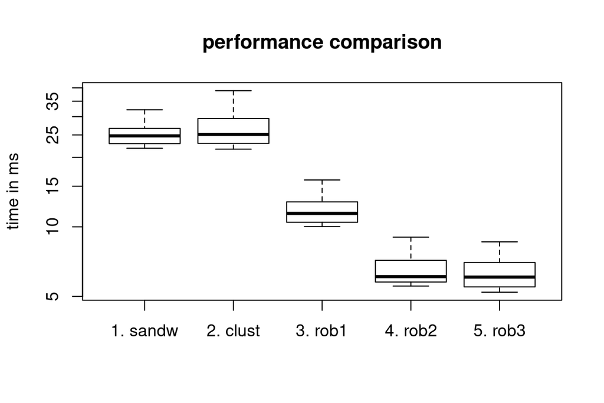

As expected, `lm/sandwich` and `lm.cluster` have similar run times. `lm_robust` is faster for all three configurations (3. to 5.) and is especially fast when estimating Stata SEs (4. and 5.). With our example data, specifying `fixed_effects` (5.) doesn’t seem to speed up the calculations.

## Conclusion

We’ve seen that it’s important to account for clusters in data when estimating model parameters, since ignoring this fact will likely result in overestimated precision which in turn can lead to wrong inference. R provides many ways to estimate clustered SEs. The packages `sandwich` and `lmtest` provide a rich set of tools for this task (and also for other types of robust SEs) and work with `lm` and other kinds of models. `lm.cluster` from the miceadds package provides a more convenient wrapper around `sandwich` and `lmtest`. However, users should be careful to not forget to pass along the separate cluster robust covariance matrix for post-estimation tasks. This is something users don’t need to care for when using `lm_robust` from the estimatr package, since the covariance matrix is not separate from the fitted model object. Another advantage is that `lm_robust` seems to be faster than the other options.

The source code for this article can be [found on GitHub](https://github.com/WZBSocialScienceCenter/r_clustered_se).

## References

Blair, Graeme, Jasper Cooper, Alexander Coppock, and Macartan Humphreys. 2019. “Declaring and Diagnosing Research Designs.” *American Political Science Review* 113 (3): 838–59. https://doi.org/10.1017/S0003055419000194.

Cameron, A Colin, and Douglas L Miller. 2013. “A Practitioner’s Guide to Cluster-Robust Inference,” 60. http://cameron.econ.ucdavis.edu/research/Cameron_Miller_Cluster_Robust_October152013.pdf.

Roberts, Molly. 2013. “Robust and Clustered Standard Errors.” https://projects.iq.harvard.edu/files/gov2001/files/sesection_5.pdf.

Sheather, Simon. 2009. *A Modern Approach to Regression with R*. Springer Texts in Statistics. New York: Springer-Verlag. https://doi.org/10.1007/978-0-387-09608-7.

Zeileis, Achim, Susanne Köll, and Nathaniel Graham. 2020. “Various Versatile Variances: An Object-Oriented Implementation of Clustered Covariances in *R*.” *Journal of Statistical Software* 95 (1). https://doi.org/10.18637/jss.v095.i01.

[^1]: It is not always necessary to use an FE model and you can very well estimate robust SEs from clustered data also without FEs.
[^2]: This is called sandwich estimator because of the structure of the formula: Between two slices of bread $(X^TX)^{-1}$ there is the meat $X^T \boldsymbol\Omega X$.
[^3]: Plugging in $\boldsymbol\Omega = \hat\sigma^2I$ in eq. 2 gives $\hat V[\hat\beta] = \hat\sigma^2 (X^TX)^{-1} X^T X (X^TX)^{-1}$ which reduces to eq. 1. because $(X^TX)^{-1} (X^T X) = I.$
[^4]: Once again a strange package name. Unlike *sandwich* this package name is not derived from a formula, but simply stands for *add*itional functionality for imputation with the *mice* package – and just happens to include clustered SE estimation.
[^5]: Note that this time we have to use the “bare” unquoted variable name – not a formula, not a string. Every package has a different policy!
[^6]: The standard `vcov` function will return the correct (cluster robust) covariance matrix for a fitted `lm_robust` model, whereas it will return the “classic” covariance matrix for a fitted `lm` model.